# A Study of Carbon Emissions in the US

Rogelio Caballero

November 13, 2016

The following is a commentary to my answers to the Final Project of Exporatory Data Analysis course, Data Science Specilization, Johns Hopkins University on Coursera.

The idea was to make an exploratory analysis of carbon emissions in the US as a function of the variables: county, source of emission and time (1999 - 2008).

## Data and Package imports

The first step was to import all packages that we were going to use through the exercises.

I decided to include *ggplot2* because of it was mandatory for a couple of questions but also for its convenience and intuitive notation.

*dplyr* package was also included because of its elegant notation and efficient  
work with large data frames.

```r
library(dplyr)
```

```r
library(ggplot2)
```

The emissions data was contained in an *.rds* file called *summarySCC_PM25.rds* that it’s going to be imported and saved to the *NEI* data frame. Since it is a pretty large file, the use of *dplyr* is justified.

```r
NEI <- readRDS("./summarySCC_PM25.rds")
```

We also want to import the file *Source_Classification_Code.rds* that contains the names and information about the source ID number that appear in the *SCC* column of *NEI*.

```r
SCC <- readRDS("./Source_Classification_Code.rds")
```

What follows are the answers to each one of the 6 questions of the project.

## Question 1: Total emissions by year.

*Have total emissions from PM2.5 decreased in the United States from 1999 to 2008? Using the base plotting system, make a plot showing the total PM2.5 emission from all sources for each of the years 1999, 2002, 2005, and 2008?*

To answer this question we need to collapse *NEI* data frame by year, taking the sum of all emissions.

```r
em_by_year <- aggregate(NEI$Emissions, list(NEI$year), sum)
names(em_by_year) <- c("year", "total_emissions")
```

Observe that it is necessary to cast the year column to class *list* in order to apply the function aggregate.

The following chunk will produce the plot.

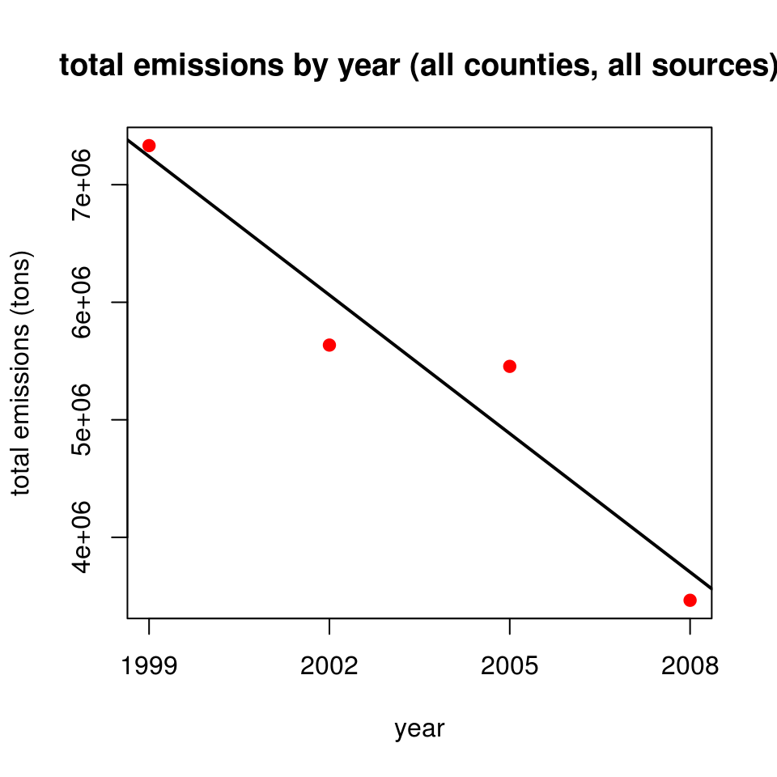

```r
with(em_by_year, plot(year, total_emissions, xlab = "year",
                      ylab = "total emissions (tons)",
                      pch = 19,
                      col = "red",
                      xaxt = "n"))

# assigning ticks to x axis with the years of
# interest
axis(side = 1, at = c(1999,2002,2005,2008))

# plotting linear model to show decreasing tendency
model <- lm(em_by_year$total_emissions ~ em_by_year$year)
abline(model, lwd = 2)

title("total emissions by year (all counties, all sources)")
```

Though it was not mandatory, I included a linear model to show the decreasing trend.

## Question 2: Emissions in Baltimore City by year.

*Have total emissions from PM2.5 decreased in the Baltimore City, Maryland (fips == “24510”) from 1999 to 2008? Use the base plotting system to make a plot answering this question.*

This question requires to filter *NEI* by zip code (column *fips*) and collapse the resulting data frame by year, taking sum:

```r
NEI1 <- NEI %>% filter(fips == "24510") %>%
        aggregate(Emissions ~ year, data = ., sum)
```

I learned how to use the magritte “%>%” operator with this question. Now, I can’t stop using it :)

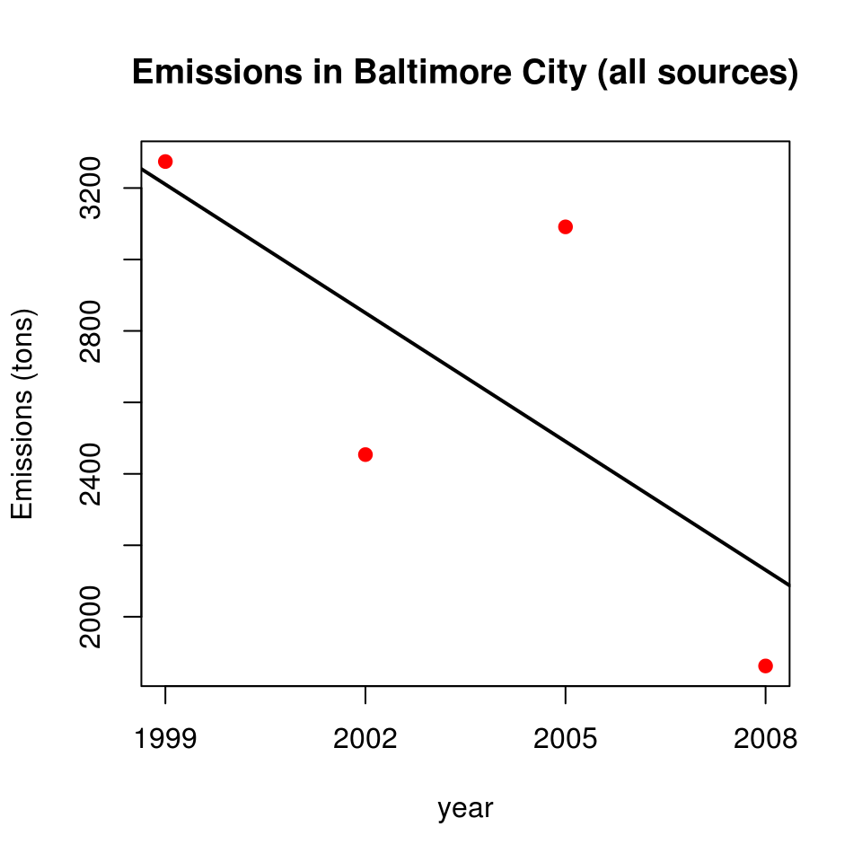

```r
with(NEI1, plot(year, Emissions, xlab = "year",
                      ylab = "Emissions (tons)",
                      pch = 19,
                      col = "red",
                      xaxt = "n"))

# assigning ticks to x axis with the years of
# interest
axis(side = 1, at = c(1999,2002,2005,2008))

# plotting linear model to show decreasing tendency
model <- lm(NEI1$Emissions ~ NEI1$year)
abline(model, lwd = 2)

title("Emissions in Baltimore City (all sources)")
```